# Bayesian GLM Part1

# 6 MCMC sampling diagnostics

**MCMC sampling behaviour**

Since the purpose of the MCMC sampling is to estimate the posterior of an unknown joint likelihood, it is important that we explore a range of diagnostics designed to help identify when the resulting likelihood might not be accurate.

- **traceplots** - plots of the individual draws in sequence. Traces that resemble noise suggest that all likelihood features are likely to have be traversed. Obvious steps or blocks of noise are likely to represent distinct features and could imply that there are yet other features that have not yet been traversed - necessitating additional iterations. Furthermore, each chain should be indistinguishable from the others
- **autocorrelation function** - plots of the degree of correlation between pairs of draws for a range of lags (distance along the chains). High levels of correlation (after a lag of 0, which is correlating each draw with itself) suggests a lack of independence between the draws and that therefore, summaries such as mean and median will be biased estimates. Ideally, all non-zero lag correlations should be less than 0.2.
- **convergence diagnostics** - there are a range of diagnostics aimed at exploring whether the multiple chains are likely to have converged upon similar posteriors
  - **R hat** - this metric compares between and within chain model parameter estimates, with the expectation that if the chains have converged, the between and within rank normalised estimates should be very similar (and Rhat should be close to 1). The more one chains deviates from the others, the higher the Rhat value. Values less than 1.05 are considered evidence of convergence.
  - **Bulk ESS** - this is a measure of the effective sample size from the whole (bulk) of the posterior and is a good measure of the sampling efficiency of draws across the entire posterior
  - **Tail ESS** - this is a measure of the effective sample size from the 5% and 95% quantiles (tails) of the posterior and is a good measure of the sampling efficiency of draws from the tail (areas of the posterior with least support and where samplers can get stuck).

`available_mcmc()`

| Package | Description | function | rstanarm | brms |
| --- | --- | --- | --- | --- |
| bayesplot | Traceplot | `mcmc_trace` | `plot(mod, plotfun='trace')` | `mcmc_plot(mod, type='trace')` |
|  | Density plot | `mcmc_dens` | `plot(mod, plotfun='dens')` | `mcmc_plot(mod, type='dens')` |
|  | Density & Trace | `mcmc_combo` | `plot(mod, plotfun='combo')` | `mcmc_plot(mod, type='combo')` |
|  | ACF | `mcmc_acf_bar` | `plot(mod, plotfun='acf_bar')` | `mcmc_plot(mod, type='acf_bar')` |
|  | Rhat hist | `mcmc_rhat_hist` | `plot(mod, plotfun='rhat_hist')` | `mcmc_plot(mod, type='rhat_hist')` |
|  | No. Effective | `mcmc_neff_hist` | `plot(mod, plotfun='neff_hist')` | `mcmc_plot(mod, type='neff_hist')` |
| rstan | Traceplot | `stan_trace` | `stan_trace(mod)` | `stan_trace(mod)` |
|  | ACF | `stan_ac` | `stan_ac(mod)` | `stan_ac(mod)` |
|  | Rhat | `stan_rhat` | `stan_rhat(mod)` | `stan_rhat(mod)` |
|  | No. Effective | `stan_ess` | `stan_ess(mod)` | `stan_ess(mod)` |
|  | Density plot | `stan_dens` | `stan_dens(mod)` | `stan_dens(mod)` |
| ggmcmc | Traceplot | `ggs_traceplot` | `ggs_traceplot(ggs(mod))` | `ggs_traceplot(ggs(mod))` |
|  | ACF | `ggs_autocorrelation` | `ggs_autocorrelation(ggs(mod))` | `ggs_autocorrelation(ggs(mod))` |
|  | Rhat | `ggs_Rhat` | `ggs_Rhat(ggs(mod))` | `ggs_Rhat(ggs(mod))` |
|  | No. Effective | `ggs_effective` | `ggs_effective(ggs(mod))` | `ggs_effective(ggs(mod))` |
|  | Cross correlation | `ggs_crosscorrelation` | `ggs_crosscorrelation(ggs(mod))` | `ggs_crosscorrelation(ggs(mod))` |
|  | Scale reduction | `ggs_grb` | `ggs_grb(ggs(mod))` | `ggs_grb(ggs(mod))` |

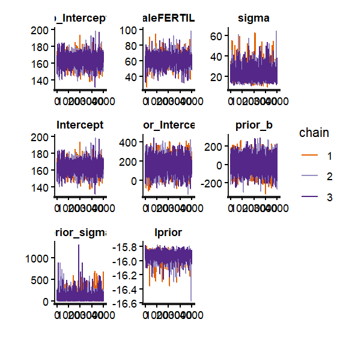

```r
fert_brm3$fit |> stan_trace()
```

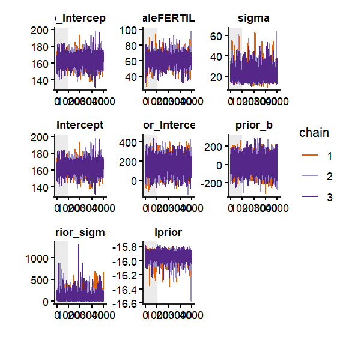

```r
#focused on the top 3
#well-mixed
#sigma stops at y=0 so makes sense that it doesn't look symmetrical

#include warmup to see if it was needed
fert_brm3$fit |> stan_trace(inc_warmup = TRUE)
```

```r
#in this case we could've done with a smaller warm up
```

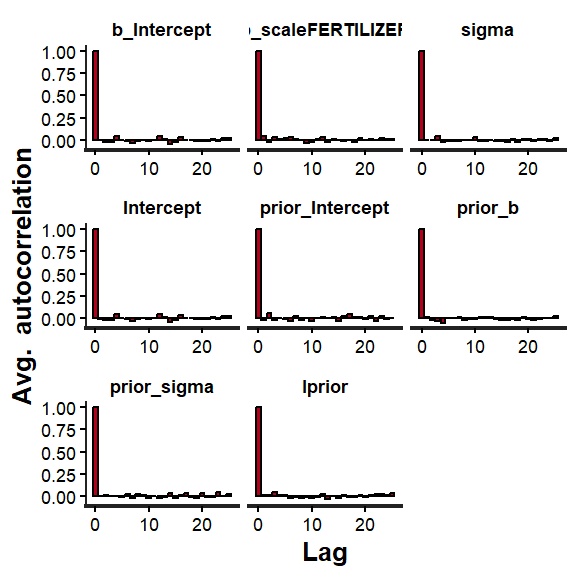

```r
fert_brm3$fit |> stan_ac()
```

```r
#standard to have a bar at 0
#at a lag of 1 (x-axis) we don't want to have large autocorrelation --> no bias between draws
#therefore, thinning was adequate
```

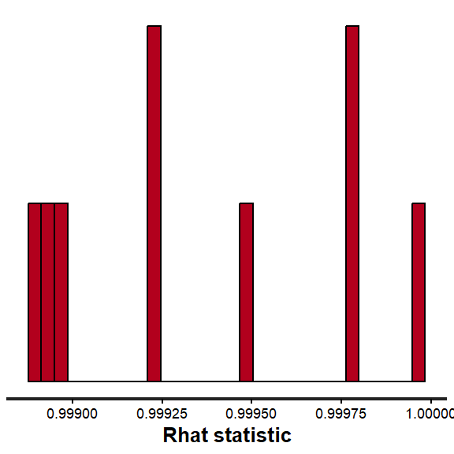

```r
#how well did chains converge
fert_brm3$fit |> stan_rhat()
```

```r
#want values <1.01
#if they are above 1.01 then the chains were different from each other
      # ^ might need to add more iterations or check priors
```

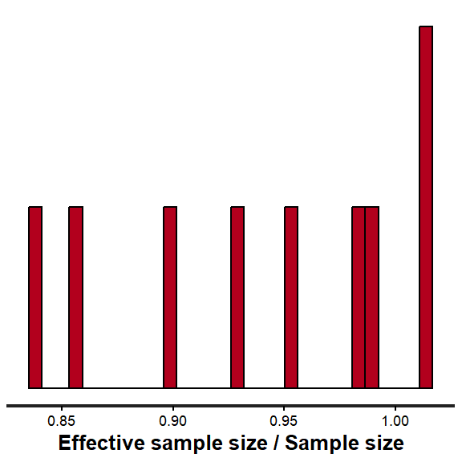

```r
fert_brm3$fit |> stan_ess()
```

```r
#uses no u turn sampler (NUTS) --> not your actual data
#tells us how many draws were effective out of all of them
#want this to be >0.5, and closer to 1 the better
#its okay if they are <0.5, but this means the model isn't efficient and the priors were probably too large,
#causing the sampler to go too far
```

# 7 Model validation

**Posterior probability checks**

`available_ppc()`

| Package | Description | function | rstanarm | brms |
| --- | --- | --- | --- | --- |
| bayesplot | Density overlay | `ppc_dens_overlay` | `pp_check(mod, plotfun='dens_overlay')` | `pp_check(mod, type='dens_overlay')` |
|  | Obs vs Pred error | `ppc_error_scatter_avg` | `pp_check(mod, plotfun='error_scatter_avg')` | `pp_check(mod, type='error_scatter_avg')` |
|  | Pred error vs x | `ppc_error_scatter_avg_vs_x` | `pp_check(mod, x=, plotfun='error_scatter_avg_vs_x')` | `pp_check(mod, x=, type='error_scatter_avg_vs_x')` |
|  | Preds vs x | `ppc_intervals` | `pp_check(mod, x=, plotfun='intervals')` | `pp_check(mod, x=, type='intervals')` |
|  | Partial plot | `ppc_ribbon` | `pp_check(mod, x=, plotfun='ribbon')` | `pp_check(mod, x=, type='ribbon')` |

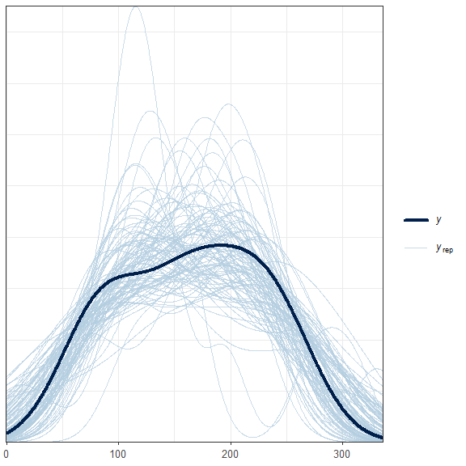

```r
fert_brm3 |> pp_check(type = 'dens_overlay', ndraws=100)
```

```r
#dark line is actual distribution of our data
#our model reconstructs the data quite well
```

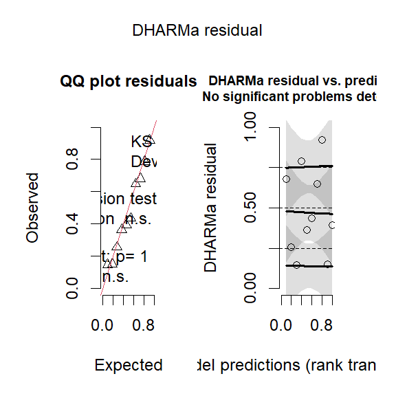

```r
#fert.resids <- make_brms_dharma_res(fert_brm3, integerResponse = FALSE)
#testUniformity(fert.resids)
#plotResiduals(fert.resids)

#another option
preds <- fert_brm3 |> posterior_predict(ndraws=250, summary=FALSE)
fert.resids <- createDHARMa(simulatedResponse = t(preds),
                            observedResponse = fert$YIELD,
                            fittedPredictedResponse = apply(preds, 2, median),
                            integerResponse = FALSE)
fert.resids |> plot()
```

```r
#QQ Plot: plots quantiles (median, upper, lower, etc)
#straight line applies that residuals follow nominated distribution (normal in this case)
#you want straight line
#KS: Smirnoff test for conformity to distribution --> if it was significant, maybe pay attention to it and see if you can change anything --> but don't blindly accept this
#Dispersion: ratio of variance to the mean --> for normal distribution we want close to 1
#Outlier test: if in red, check and see if it really is a problem

#residual plot: dont want any patterns (fan shape = unequal variances)
```

# 8 Partial effects plots

```
Ignoring unknown labels:
• fill : "NA"
• colour : "NA"
Ignoring unknown labels:
• fill : "NA"
• colour : "NA"
```

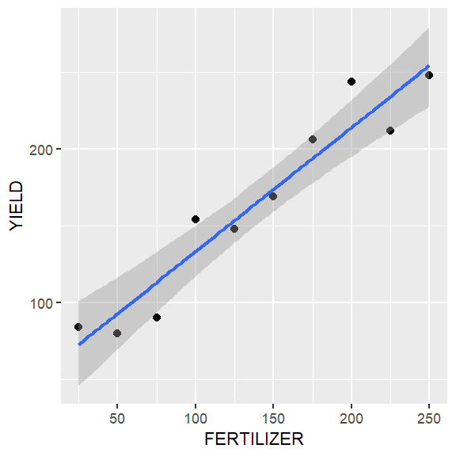

```r
fert_brm3 |> conditional_effects() |> plot(points = TRUE)
```

```r
fert_brm3 |> summary()
```

```
 Family: gaussian
  Links: mu = identity
Formula: YIELD ~ scale(FERTILIZER)
   Data: fert (Number of observations: 10)
  Draws: 3 chains, each with iter = 5000; warmup = 1000; thin = 5;
         total post-warmup draws = 2400

Regression Coefficients:
                Estimate Est.Error l-95% CI u-95% CI Rhat Bulk_ESS Tail_ESS
Intercept         163.63      7.26   149.41   178.18 1.00     2431     2046
scaleFERTILIZER    61.14      7.71    45.66    75.92 1.00     2161     2075

Further Distributional Parameters:
      Estimate Est.Error l-95% CI u-95% CI Rhat Bulk_ESS Tail_ESS
sigma    22.33      6.81    13.21    39.25 1.00     2201     2330

Draws were sampled using sample(hmc). For each parameter, Bulk_ESS
and Tail_ESS are effective sample size measures, and Rhat is the potential
scale reduction factor on split chains (at convergence, Rhat = 1).
```

```r
#CI = credibility interval
#you want Effective sample size (ESS) >1000 --> ideally close to the total post-warmup draws
#main thing that establishes if there's a relationship or not is the slope (scaleFERTILIZER)
  # for every one unit change in scaleFERTILIZER we expect the YIELD to increase by 61.14
  #can say we're 95% sure the slope is positive, strong evidence of an effect of fertilizer concentration because   CI doesn't include 0

#PROBABILITY SCALE:
# >0.85 = evidence for that is weak
# <0.85 = no evidence at all
# >0.9 = there is evidence
# >0.95 = the evidence is strong
```

```r
fert_brm3 |>
  summarise_draws(median,
                HDInterval::hdi,
                rhat, length, ess_bulk, ess_tail)
```

```
# A tibble: 9 × 8
  variable          median      lower upper  rhat length ess_bulk ess_tail
  <chr>              <dbl>      <dbl> <dbl> <dbl>  <dbl>    <dbl>    <dbl>
1 b_Intercept       164.    149.      178.  1.00    2400    2431.    2046.
2 b_scaleFERTILIZER  61.3    45.7      76.0 1.000   2400    2161.    2075.
3 sigma              20.9    12.4      36.2 1.000   2400    2201.    2330.
4 Intercept         164.    149.      178.  1.00    2400    2431.    2046.
5 prior_Intercept   160.    -20.9     328.  1.000   2400    2403.    2097.
6 prior_b            -3.91 -177.      184.  1.00    2400    2374.    2330.
7 prior_sigma        68.7     0.00623 289.  1.00    2400    2285.    2289.
8 lprior            -15.9   -16.1     -15.8 1.00    2400    2121.    2063.
9 lp__              -57.0   -60.2     -55.6 1.00    2400    2320.    2082.
```

```r
#HDI = highest probability density intervals --> more robust than quantiles
#length = number of draws
#efficency of sampling the bulk and tails of the distribution, low ess in tails = priors probably too wide
```

```r
fert_brm3 |> as_draws_df()
```

```
# A draws_df: 800 iterations, 3 chains, and 9 variables
   b_Intercept b_scaleFERTILIZER sigma Intercept prior_Intercept prior_b
1          155                63    17       155              16     3.6
2          172                54    18       172             206   -46.0
3          153                48    35       153             330   -13.6
4          152                69    25       152             212   130.5
5          162                64    19       162             276    -1.8
6          170                56    18       170             188   177.0
7          162                64    18       162             247    57.5
8          175                64    28       175             188    44.1
9          163                60    14       163              82    39.1
10         161                64    32       161             122   191.2
   prior_sigma lprior
1          209    -16
2          149    -16
3           68    -16
4           50    -16
5          123    -16
6           45    -16
7           37    -16
8          160    -16
9           43    -16
10          21    -16
# ... with 2390 more draws, and 1 more variables
# ... hidden reserved variables {'.chain', '.iteration', '.draw'}
```

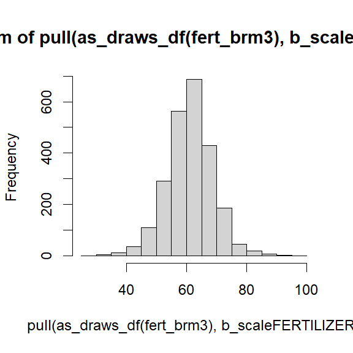

```r
#you get from Bayesian models a distribution of slope and a distribution of intercept

#want to look more closely at the slope
#histogram
fert_brm3 |>
  as_draws_df() |>
  pull(b_scaleFERTILIZER) |>
  hist()
```

```r
#median
fert_brm3 |>
  as_draws_df() |>
  pull(b_scaleFERTILIZER) |>
  median()
```

```
[1] 61.30294
```

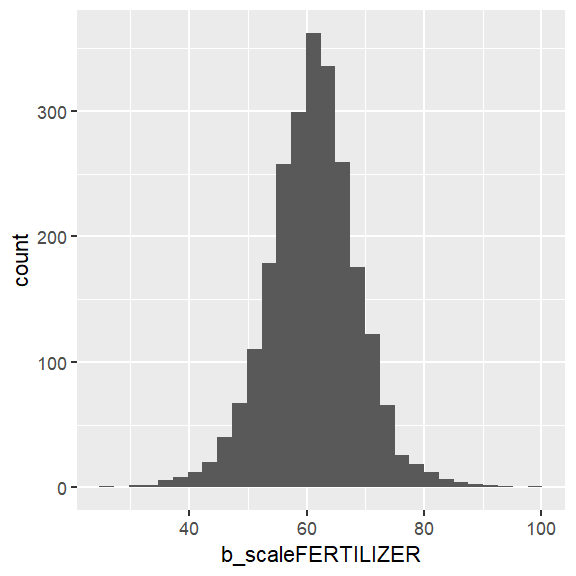

```r
#fancy ggplot histogram
fert_brm3 |>
  as_draws_df() |>
  ggplot(aes(x = b_scaleFERTILIZER)) +
  geom_histogram()
```

```r
#distribution is all above 0 so we are really sure there is a relationship

#what % are above 0?
#do it manually
x <- fert_brm3 |>
  as_draws_df() |>
  pull(b_scaleFERTILIZER)

x > 0
```

[output not shown]

[output cut: 157 more lines]

```r
sum(x > 0)
```

```
[1] 2400
```

```r
sum(x > 0) / 2400
```

```
[1] 1
```

```r
#OR
mean(x > 0)
```

```
[1] 1
```

```r
#correct way to do this moving forward
#P = bayesian probability
#~mean = if you need () in the function then use the ~
fert_brm3 |>
  summarise_draws(median,
                HDInterval::hdi,
                P = ~mean(.x > 0),
                rhat, length, ess_bulk, ess_tail)
```

```
# A tibble: 9 × 9
  variable          median      lower upper     P  rhat length ess_bulk ess_tail
  <chr>              <dbl>      <dbl> <dbl> <dbl> <dbl>  <dbl>    <dbl>    <dbl>
1 b_Intercept       164.    149.      178.  1     1.00    2400    2431.    2046.
2 b_scaleFERTILIZER  61.3    45.7      76.0 1     1.000   2400    2161.    2075.
3 sigma              20.9    12.4      36.2 1     1.000   2400    2201.    2330.
4 Intercept         164.    149.      178.  1     1.00    2400    2431.    2046.
5 prior_Intercept   160.    -20.9     328.  0.964 1.000   2400    2403.    2097.
6 prior_b            -3.91 -177.      184.  0.482 1.00    2400    2374.    2330.
7 prior_sigma        68.7     0.00623 289.  1     1.00    2400    2285.    2289.
8 lprior            -15.9   -16.1     -15.8 0     1.00    2400    2121.    2063.
9 lp__              -57.0   -60.2     -55.6 0     1.00    2400    2320.    2082.
```

```r
#P is only important for the slope b_scaleFERTILIZER. Ignore it for Intercept and sigma

#get rid of things we don't need
fert_brm3 |>
  as_draws_df() |>
  dplyr::select(matches("^b_.*|^sigma$")) |> #pattern must start with b_ or sigma exactly
  summarise_draws(median,
                HDInterval::hdi,
                P = ~mean(.x > 0),
                rhat, length, ess_bulk, ess_tail)
```

```
# A tibble: 3 × 9
  variable          median lower upper     P  rhat length ess_bulk ess_tail
  <chr>              <dbl> <dbl> <dbl> <dbl> <dbl>  <dbl>    <dbl>    <dbl>
1 b_Intercept        164.  149.  178.      1 1.000   2400    2424.    1991.
2 b_scaleFERTILIZER   61.3  45.7  76.0     1 1.000   2400    2117.    2052.
3 sigma               20.9  12.4  36.2     1 1.000   2400    2192.    2322.
```

```r
fert_brm3 |> bayes_R2(summary=FALSE) |>
  median_hdci()
```

```
          y      ymin      ymax .width .point .interval
1 0.9195638 0.8276093 0.9273001   0.95 median      hdci
```

```r
#y = R^2, 92% of YIELD can be explained by FERTILIZER
```

Conclusion: Fertilizer has a strong effect on yield (cite slope).

#now look at other questions

```r
fert_brm3 |> avg_slopes() #for every unit change in fertilizer, yield increases by 0.8
```

```
 Estimate 2.5 % 97.5 %
     0.81 0.603      1

Term: FERTILIZER
Type: response
Comparison: dY/dX
```

```r
sd(fert$FERTILIZER) #original SD
```

```
[1] 75.69126
```

```r
#we divide the slope by the original SD to scle BACK to the original values
fert_brm3 |>
  as_draws_df() |>
  mutate(slope = b_scaleFERTILIZER / 75.69) |>
  summarise_draws(median, HDInterval::hdi)
```

```
# A tibble: 10 × 4
   variable           median      lower  upper
   <chr>               <dbl>      <dbl>  <dbl>
 1 b_Intercept       164.     149.      178.
 2 b_scaleFERTILIZER  61.3     45.7      76.0
 3 sigma              20.9     12.4      36.2
 4 Intercept         164.     149.      178.
 5 prior_Intercept   160.     -20.9     328.
 6 prior_b            -3.91  -177.      184.
 7 prior_sigma        68.7      0.00623 289.
 8 lprior            -15.9    -16.1     -15.8
 9 lp__              -57.0    -60.2     -55.6
10 slope               0.810    0.603     1.00
```

# 9 Model investigation

Rather than simply return point estimates of each of the model parameters, Bayesian analyses capture the full posterior of each parameter. These are typically stored within the `list` structure of the output object.

As with most statistical routines, the overloaded `summary()` function provides an overall summary of the model parameters. Typically, the summaries will include the means / medians along with credibility intervals and perhaps convergence diagnostics (such as R hat). However, more thorough investigation and analysis of the parameter posteriors requires access to the full posteriors.

There is currently a plethora of functions for extracting the full posteriors from models. In part, this is a reflection of a rapidly evolving space with numerous packages providing near equivalent functionality (it should also be noted, that over time, many of the functions have been deprecated due to inconsistencies in their names). Broadly speaking, the functions focus on draws from the posterior of either the parameters (intercept, slope, standard deviation etc), **linear predictor**, **expected values** or **predicted values**. The distinction between the latter three are highlighted in the following table.

| Property | Description |
| --- | --- |
| linear predictors | values predicted on the link scale |
| expected values | predictions (on response scale) without residual error (predicting expected mean outcome(s)) |
| predicted values | predictions (on response scale) that incorporate residual error |
| fitted values | predictions on the response scale |

The following table lists the various ways of extracting the full posteriors of the model parameters parameters, **expected** values and **predicted** values. The crossed out items are now deprecated and function with a namespace of `__` mean that the functionality is provided via a range of packages.

| Function | Values | Description |
| --- | --- | --- |
| `__::as.matrix()` | Parameters | Returns $n\times p$ matrix |
| `__::as.data.frame()` | Parameters | Returns $n\times p$ data.frame |
| `__::as_tibble()` | Parameters | Returns $n\times p$ tibble |
| `posterior::as_draws_df()` | Parameters | Returns $n\times p$ data.frame with additional info about chain, interaction and draw |
| `brms::posterior_samples()` | Parameters | Returns $n\times p$ data.frame |
| `tidybayes::tidy_draws()` | Parameters | Returns $n\times p$ tibble with addition info about the chain, iteration and draw |
| `rstan::extract()` | Parameters | Returns a $p$ length list of $n$ length vectors |
| `tidybayes::spread_draws()` | Parameters | Returns $n\times r$ tibble with additional info about chain, interaction and draw |
| `tidybayes::gather_draws()` | Parameters | Returns a gathered `spread_draws` tibble with additional info about chain, interaction and draw |
| `rstanarm::posterior_linpred()` | Linear predictors | Returns $n\times N$ tibble on the link scale |
| `brms::posterior_linpred()` | Linear predictors | Returns $n\times N$ tibble on the link scale |
| `tidybayes::linpred_draws()` | Linear predictors | Returns tibble with $nN rows and `.linpred` on the link scale additional info about chain, interaction and draw |
| `rstanarm::posterior_epred()` | Expected values | Returns $n\times N$ tibble on the response scale |
| `brms::posterior_epred()` | Expected values | Returns $n\times N$ tibble on the response scale |
| `tidybayes::epred_draws()` | Expected values | Returns tibble with $nN rows and `.epred` on the response scale additional info about chain, interaction and draw |
| `rstanarm::posterior_predict()` | Expected values | Returns $n\times N$ tibble of predictions (including residuals) on the response scale |
| `brms::posterior_predict()` | Expected values | Returns $n\times N$ tibble of predictions (including residuals) on the response scale |
| `tidybayes::predicted_draws()` | Expected values | Returns tibble with $nN rows and `.prediction` (including residuals) on the response scale additional info about chain, interaction and draw |

where $n$ is the number of MCMC samples and $p$ is the number of parameters to estimate, $N$ is the number of newdata rows and $r$ is the number of requested parameters. For the `tidybayes` versions in the table above, the function expects a model to be the first parameter (and a dataframe to be the second). There are also `add_` versions which expect a dataframe to be the first argument and the model to be the second. These alternatives facilitate pipings with different starting objects.

| Function | Description |
| --- | --- |
| `median_qi` | Median and quantiles of specific columns |
| `median_hdi` | Median and Highest Probability Density Interval of specific columns |
| `median_hdci` | Median and continuous Highest Probability Density Interval of specific columns |
| `tidyMCMC` | Median/mean and quantiles/hpd of all columns |